# Biomass chane at different levels of predation

Faith Jones

16 June 2017

Here i present the mixed model results for change in biomass of predators. There are three levels of predation: Wide (group 2 and 3 species), Middle (group2) and Narrow(Hoplias and Crenicichla). Only teh data from July/august is incuded so I could use the 2016 data. Also the survey eatken in 2010 is removed sure to sampling differences.

# Narrow level predation definition

Here is the raw plot of predator biomass agaist time, and the plot of log2 biomass against time. There is a lot of variability.

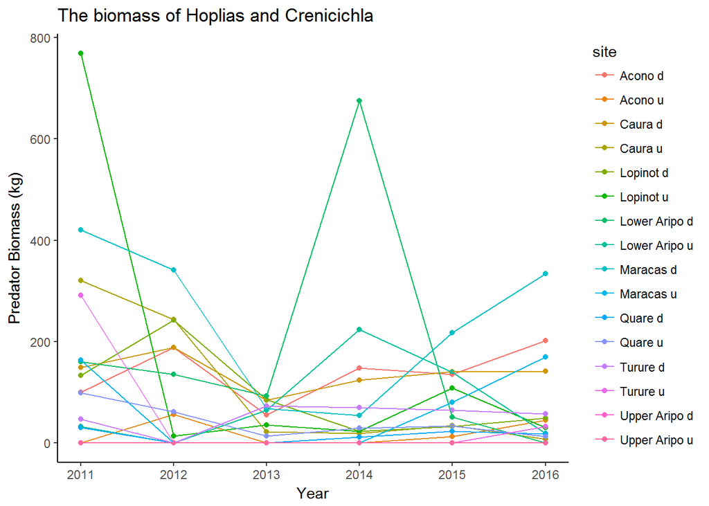

```r
BioPlot <- ggplot(FishDataTot, aes(x = Year, y = BiomassSum, col = site, group = site))
BioPlot + geom_point() +
    geom_line() +
    theme_classic() +
    labs(title="The biomass of Hoplias and Crenicichla", y = "Predator Biomass (kg)")
```

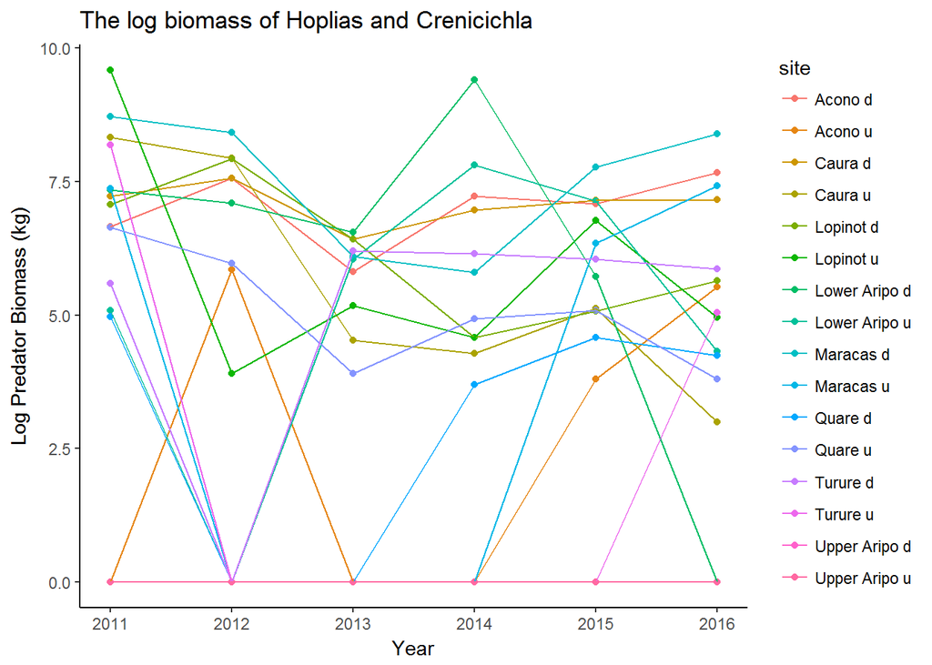

```r
BioPlotLog <- ggplot(FishDataTot, aes(x = Year, y = LogBiomass, col = site, group = site))
BioPlotLog + geom_point() +
    geom_line() +
    theme_classic() +
    labs(title="The log biomass of Hoplias and Crenicichla", y = "Log Predator Biomass (kg)")
```

Next is the mixed model results and plot of slopes of the sites

```r
bioMLog <- lmer(LogBiomass ~ meanCentredYear + (meanCentredYear|site), data = FishDataTot)
summary(bioMLog)
```

```
## Linear mixed model fit by REML ['lmerMod']
## Formula: LogBiomass ~ meanCentredYear + (meanCentredYear | site)
##    Data: FishDataTot
##
## REML criterion at convergence: 455.3
##
## Scaled residuals:
##      Min       1Q   Median       3Q      Max
## -2.47947 -0.49056  0.00353  0.53203  2.57602
##
## Random effects:
##  Groups   Name            Variance Std.Dev. Corr
##  site     (Intercept)     4.77104  2.1843
##           meanCentredYear 0.02486  0.1577   -1.00
##  Residual                 4.89539  2.2126
## Number of obs: 96, groups:  site, 16
##
## Fixed effects:
##                 Estimate Std. Error t value
## (Intercept)      4.46117    0.59092   7.550
## meanCentredYear -0.07836    0.13798  -0.568
##
## Correlation of Fixed Effects:
##             (Intr)
## meanCntrdYr -0.264
```

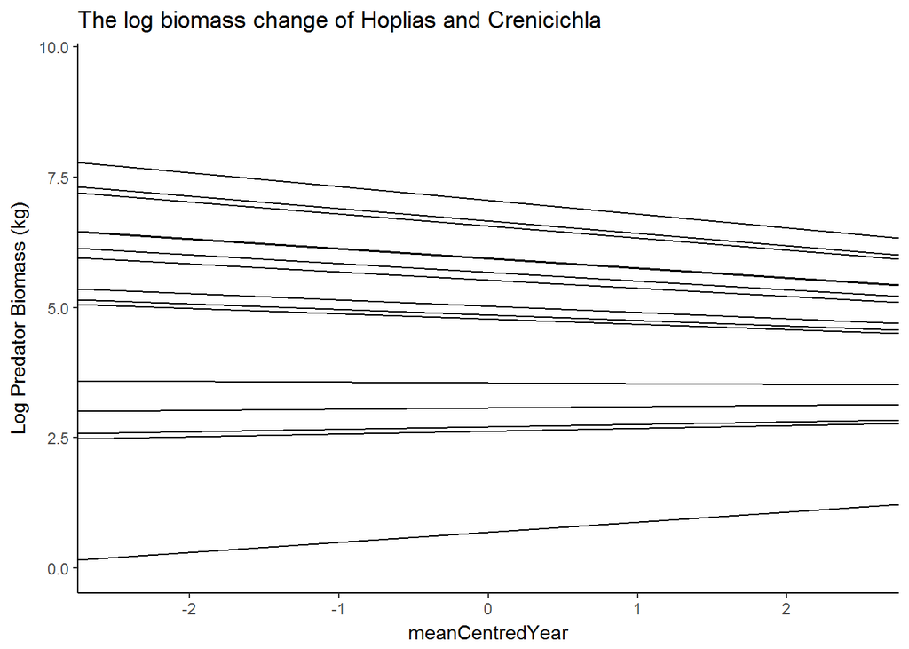

```r
#plot slopes of sites
bioMLog_Lines <- coef(bioMLog )$site[c(1:2)] # get slope and intercept of each line in model 3
names(bioMLog_Lines) <- c("intercept", "slope")

m3.plotb <- ggplot(data = FishDataTot, aes(x = meanCentredYear, y = LogBiomass)) # plot of model with varying intercept but not slope, but only main slope shown
m3.plotb + geom_blank() +
    theme_classic() +
    geom_abline(slope =bioMLog_Lines$slope, intercept = bioMLog_Lines$intercept) +
    labs(title="The log biomass change of Hoplias and Crenicichla", y = "Log Predator Biomass (kg)")
```

# Middle level predation definition

Here is the raw plot of predator biomass agaist time, and the plot of log2 biomass against time, for middel predation. There is a lot of variability.

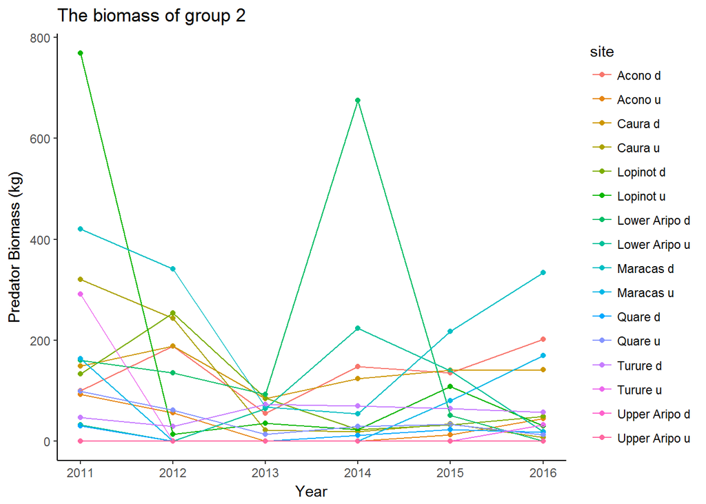

```r
BioPlotm <- ggplot(FishDataTotm, aes(x = Year, y = BiomassSum, col = site, group = site))
BioPlotm + geom_point() +
    geom_line() +
    theme_classic() +
    labs(title="The biomass of group 2", y = "Predator Biomass (kg)")
```

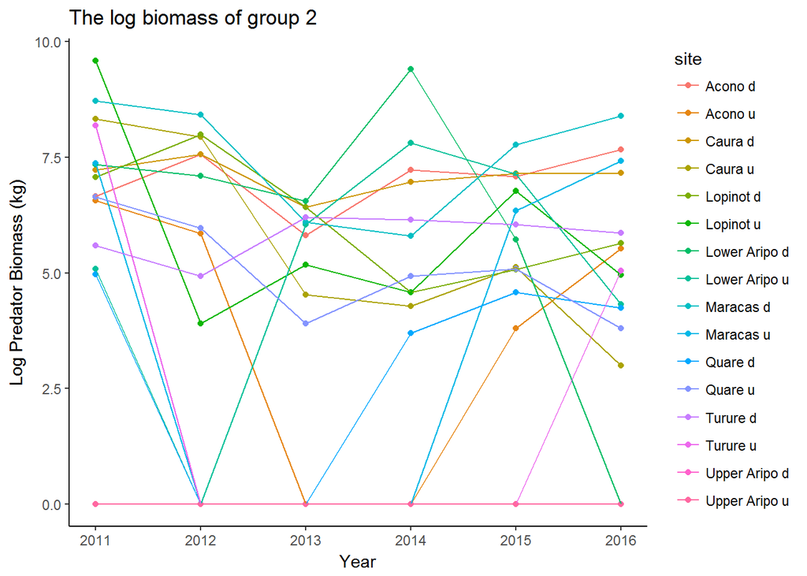

```r
BioPlotLogm <- ggplot(FishDataTotm, aes(x = Year, y = LogBiomass, col = site))
BioPlotLogm + geom_point() +
    geom_line() +
    theme_classic() +
    labs(title="The log biomass of group 2", y = "Log Predator Biomass (kg)")
```

Mixed model results and plot of slopes of the sites (Middle)

```r
bioMLogm <- lmer(LogBiomass ~ meanCentredYear + (meanCentredYear|site), data = FishDataTotm)
summary(bioMLogm)
```

```
## Linear mixed model fit by REML ['lmerMod']
## Formula: LogBiomass ~ meanCentredYear + (meanCentredYear | site)
##    Data: FishDataTotm
##
## REML criterion at convergence: 448.9
##
## Scaled residuals:
##      Min       1Q   Median       3Q      Max
## -2.51096 -0.37530  0.03168  0.49754  2.55552
##
## Random effects:
##  Groups   Name            Variance Std.Dev. Corr
##  site     (Intercept)     4.71688  2.1718
##           meanCentredYear 0.01135  0.1065   -1.00
##  Residual                 4.53902  2.1305
## Number of obs: 96, groups:  site, 16
##
## Fixed effects:
##                 Estimate Std. Error t value
## (Intercept)       4.5815     0.5849   7.833
## meanCentredYear  -0.1637     0.1301  -1.258
##
## Correlation of Fixed Effects:
##             (Intr)
## meanCntrdYr -0.190
```

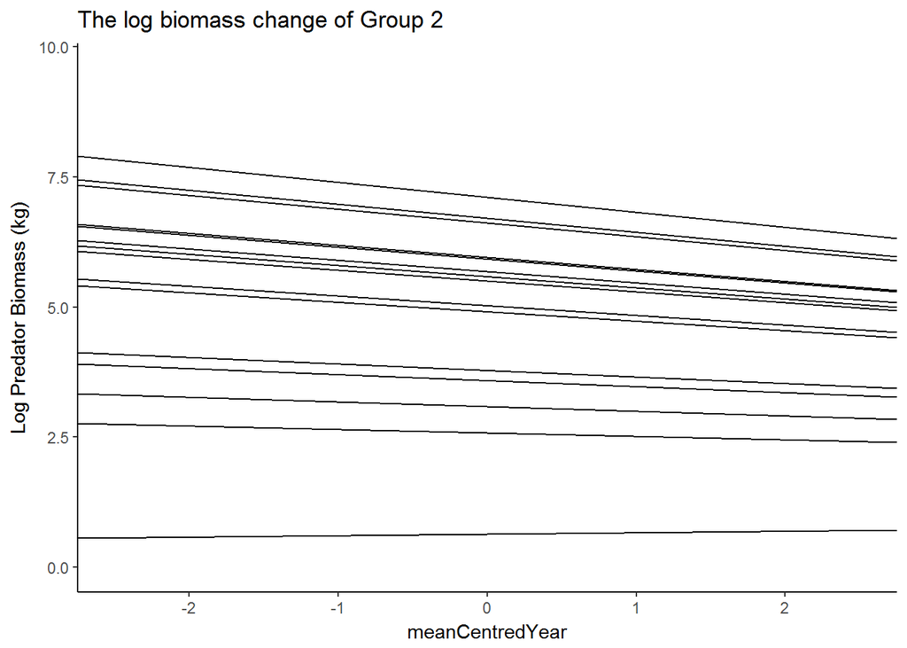

```r
#plot slopes of sites
bioMLog_Linesm <- coef(bioMLogm)$site[c(1:2)] # get slope and intercept of each line in model 3
names(bioMLog_Linesm) <- c("intercept", "slope")

m3.plotbm <- ggplot(data = FishDataTotm, aes(x = meanCentredYear, y = LogBiomass)) # plot of model with varying intercept but not slope, but only main slope shown
m3.plotbm + geom_blank() +
    theme_classic() +
    geom_abline(slope =bioMLog_Linesm$slope, intercept = bioMLog_Linesm$intercept) +
    labs(title="The log biomass change of Group 2", y = "Log Predator Biomass (kg)")
```

# Wide level predation definition

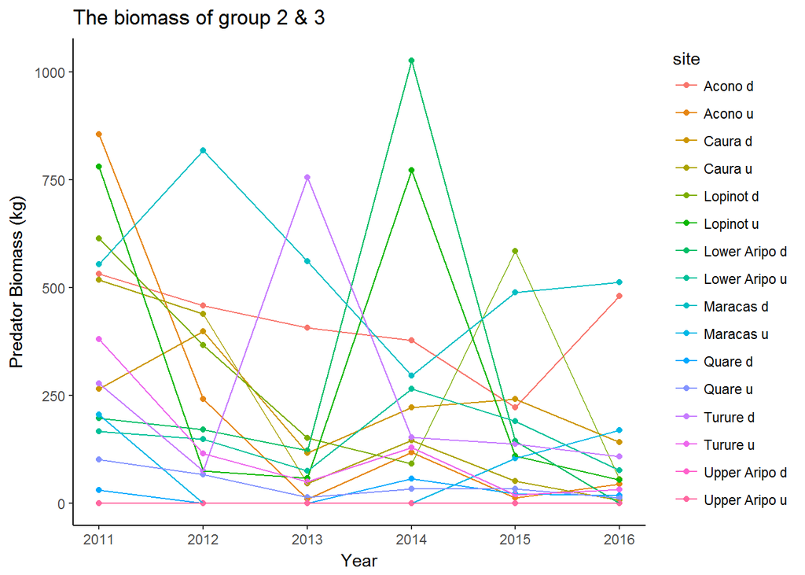

```r
BioPlotw <- ggplot(FishDataTotw, aes(x = Year, y = BiomassSum, col = site, group = site))
BioPlotw + geom_point() +
    geom_line() +
    theme_classic() +
    labs(title="The biomass of group 2 & 3", y = "Predator Biomass (kg)")
```

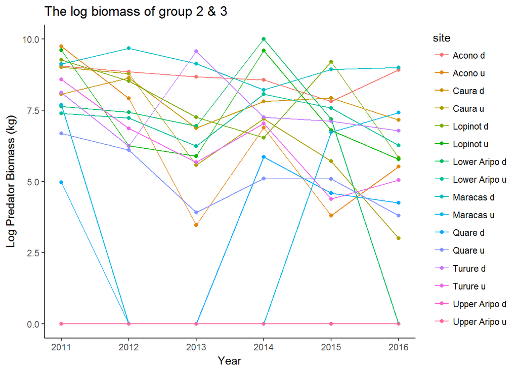

```r
BioPlotLogw <- ggplot(FishDataTotw, aes(x = Year, y = LogBiomass, col = site))
BioPlotLogw + geom_point() +
    geom_line() +
    theme_classic() +
    labs(title="The log biomass of group 2 & 3", y = "Log Predator Biomass (kg)")
```

Mixed model (wide)

```r
bioMLogw <- lmer(LogBiomass ~ meanCentredYear + (meanCentredYear|site), data = FishDataTotw)
summary(bioMLogw)
```

```
## Linear mixed model fit by REML ['lmerMod']
## Formula: LogBiomass ~ meanCentredYear + (meanCentredYear | site)
##    Data: FishDataTotw
##
## REML criterion at convergence: 426.5
##
## Scaled residuals:
##     Min      1Q  Median      3Q     Max
## -3.2073 -0.3328  0.0421  0.5084  2.2889
##
## Random effects:
##  Groups   Name            Variance Std.Dev. Corr
##  site     (Intercept)     7.0232   2.6501
##           meanCentredYear 0.0332   0.1822   -0.99
##  Residual                 3.2065   1.7907
## Number of obs: 96, groups:  site, 16
##
## Fixed effects:
##                 Estimate Std. Error t value
## (Intercept)       5.7961     0.6873   8.433
## meanCentredYear  -0.2872     0.1163  -2.469
##
## Correlation of Fixed Effects:
##             (Intr)
## meanCntrdYr -0.372
```

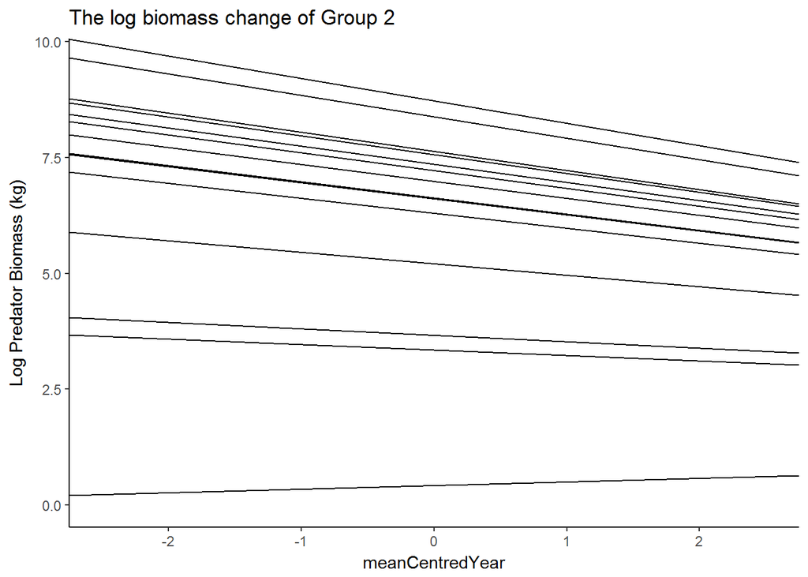

```r
#plot slopes of sites
bioMLog_Linesw <- coef(bioMLogw)$site[c(1:2)] # get slope and intercept of each line in model 3
names(bioMLog_Linesw) <- c("intercept", "slope")

m3.plotbw <- ggplot(data = FishDataTotw, aes(x = meanCentredYear, y = LogBiomass)) # plot of model with varying intercept but not slope, but only main slope shown
m3.plotbm + geom_blank() +
    theme_classic() +
    geom_abline(slope =bioMLog_Linesw$slope, intercept = bioMLog_Linesw$intercept) +
    labs(title="The log biomass change of Group 2", y = "Log Predator Biomass (kg)")
```